# Alternative plots

Pyry Toivonen

2024-09-23

# Animation

### Setup

```r
library(tidyverse) # ggplot + data management
library(sf) # For spatial data management
library(gganimate) # Animation features for ggplot
library(gifski) # for GIF rendering, doesn't necessarily had to be loaded just installed

setwd("//utuhome.utu.fi/pntoiv/AltPlotsPres") # Working directory
```

### Data import and management

For data we have GPS track data for coastal raccoon dogs and Island vector data

```r
TrackData <- read.csv("TrackData.csv")
Islands <- st_read("Islands.gpkg") # TIP: use GeoPackage format for vector data instead of shapefiles! Better handling of columns and suitability with R in my opinion.
str(TrackData)
```

```
## 'data.frame':    18392 obs. of  9 variables:
##  $ x_        : num  181759 181865 181062 180843 181126 ...
##  $ y_        : num  6699619 6699890 6700056 6700365 6700040 ...
##  $ t_        : chr  "2022-04-24 23:00:00" "2022-04-25 01:00:00" "2022-04-25 23:00:00" "2022-04-26 19:00:00" ...
##  $ ID        : chr  "R1" "R1" "R1" "R1" ...
##  $ NSD       : num  0 17.1 28.7 34.4 27.6 ...
##  $ SaarID    : int  12226 12226 12226 12226 12226 12226 12226 12226 12226 12226 ...
##  $ HDOP      : num  1 1.3 1.4 1.2 1.4 2.2 1.1 2 1.5 1.9 ...
##  $ Difference: int  NA 0 0 0 0 0 0 0 0 0 ...
##  $ IslandHop : int  NA 0 0 0 0 0 0 0 0 0 ...
```

We will work with smaller subset of the data to visualize the behavior of two raccoon dogs that partnered later on

```r
# We want date-time column to be in date-time format.
TrackData$t_ <- as.POSIXct(TrackData$t_, "%Y-%m-%d %H:%M:%S", tz="UTC")

# Filtering data only to two individuals and for dates before 2021.
TrackSubset <- TrackData %>%
   filter(ID %in% c("R3","R4")) %>%
   filter(t_ < "2021-01-01 00:00")
```

### Plotting the data and animating it

Plot the data conventionally. Here you form the basis for the animation.

Here I filter the Island data to only include the islands that the raccoon dogs visited

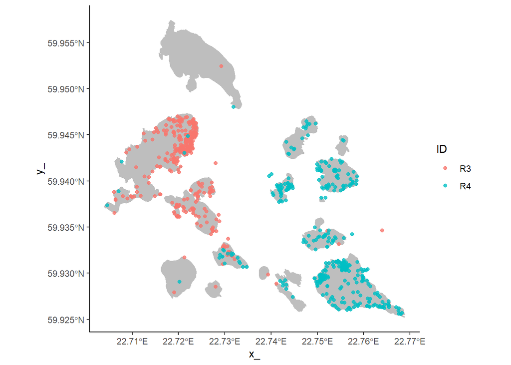

```r
p <- ggplot() +
  geom_sf(data=filter(Islands, ID %in% TrackSubset$SaarID), fill="gray", color="gray") +
  geom_point(data=TrackSubset, aes(x=x_, y=y_, color=ID), alpha=0.8) +
  theme_classic()


p
```

Here it is important that the GPS track data is plotted with geom_point and not as spatial object (geom_sf), because animation doesn’t support geom_sf(). Spatial point data can always be plotted with geom_point, because spatial coordinates can be put into X and Y axis.

Now the animation. The syntax works similar to ggplot2.

```r
Animation <- p +
  transition_time(t_)+ # Adds transition to the plot. This transition is time-based: see ?transition_time
  ease_aes('linear')+ # This is the default easing function
  ggtitle("Day: {frame_time}")

# Check how many unique dates are in the dataset
length(unique(TrackSubset$t_)) # = 434
```

```
## [1] 434
```

The number of unique dates should be our number of frames in the animation, so each date gets its own frame. When we do it like this, FPS (frames per second) means dates per second.

Now we make animation that has 434 frames and goes 3 frames per second, so it goes through 3 dates (date-time) in a second.

The width, height and resolution of the animation is experimental choice. I have found these settings to satisfy my needs. End_pause and start_pause define how many times last or first frame is repeated, default is 0.

Rendering of this GIF takes around 1 minute.

```r
GIF <- gganimate::animate(Animation, nframes=434, fps = 3,
        width=1442,
        height=731,
        res=150,
        end_pause=3,
        start_pause=3,
        renderer=gifski_renderer()) #use av-package and av_renderer() if you want a video format
```

Save the animation as gif

```r
anim_save("GIF1.gif", GIF)

# If you used av_renderer from the av package, you can save the animation as, for example, .mp4
```

[figure not shown]

# Interactive plotting

Our task is to create a plotting device which can be used to inspect easily individual data and switch between plotting style. Additionally, we want to collect data from the plot.

To achieve this we will use shiny and plotly packages and ChatGPT to write us the code.

```r
library(shiny) # For building web application for plot
library(plotly) # For interactive plots
library(tidyverse)  # For data management

# Both shiny and plotly are required

setwd("//utuhome.utu.fi/pntoiv/AltPlotsPres") # Working directory
```

```r
TrackData <- read.csv("TrackData.csv")

TrackData <- TrackData %>% mutate(X=x_, Y=y_)

TrackData$ID <- as.factor(TrackData$ID)
TrackData$t_ <- as.POSIXct(TrackData$t_, "%Y-%m-%d %H:%M:%S", tz="UTC")
```

ChatGPT prompt:

```r
“Hey! Create me a code in R using shiny and plotly. I
want this code to use data.frame named”TrackData”. Make me plot device
that where I can switch between individuals (ID column) and plot types.
I want to be able to switch between two plot types: one where X axis is
X column and Y axis is Y column, and another where X axis is t_ column
and y axis is NSD column.”
```

```r
# Sample UI
ui <- fluidPage(

  # Title
  titlePanel("TrackData Plot Device"),

  # Sidebar layout
  sidebarLayout(
    sidebarPanel(
      # Dropdown for selecting individual (ID)
      selectInput("selectedID", "Select Individual ID:",
                  choices = unique(TrackData$ID)),

      # Radio buttons for selecting plot type
      radioButtons("plotType", "Select Plot Type:",
                   choices = list("X vs Y" = "xy",
                                  "t_ vs NSD" = "tnsd"))
    ),

    # Main panel to display plot
    mainPanel(
      plotlyOutput("plot")
    )
  )
)

# Server logic
server <- function(input, output) {

  # Reactive function to filter data based on selected ID
  filteredData <- reactive({
    TrackData[TrackData$ID == input$selectedID, ]
  })

  # Plotting logic
  output$plot <- renderPlotly({
    # Get the filtered data
    data <- filteredData()

    # Plot type: X vs Y
    if (input$plotType == "xy") {
      p <- plot_ly(data, x = ~X, y = ~Y, mode = "markers", type = "scatter") %>%
        layout(title = paste("X vs Y for ID:", input$selectedID),
               xaxis = list(title = "X"),
               yaxis = list(title = "Y"))

    # Plot type: t_ vs NSD
    } else if (input$plotType == "tnsd") {
      p <- plot_ly(data, x = ~t_, y = ~NSD, mode = "markers", type = "scatter") %>%
        layout(title = paste("t_ vs NSD for ID:", input$selectedID),
               xaxis = list(title = "t_"),
               yaxis = list(title = "NSD"))
    }

    # Return the plot
    p
  })
}

# Run the application
shinyApp(ui = ui, server = server)
```

### Store start date and end date from NSD plot

```r
data <- TrackData

# Initialize the selected points data frame
selected_points <- data.frame(ID = factor(), start_date = as.Date(character()), end_date = as.Date(character()), stringsAsFactors = FALSE)

# UI
ui <- fluidPage(
  titlePanel("Interactive Event Classification"),
  sidebarLayout(
    sidebarPanel(
      selectInput("selectedID", "Select ID:", choices = levels(data$ID)),
      actionButton("reset", "Remove"),
      actionButton("refresh", "Refresh"),
      tableOutput("selected_points_table")
    ),
    mainPanel(
      plotlyOutput("plot")
    )
  )
)

# Server
server <- function(input, output, session) {
  # Reactive expression to filter data based on selected ID
  filtered_data <- reactive({
    data %>% filter(ID == input$selectedID)
  })

  # Reactive values to store start and end dates
  click_values <- reactiveValues(start_date = NULL, end_date = NULL)

  # Render Plotly plot
  output$plot <- renderPlotly({
    plot_ly(filtered_data(), x = ~t_, y = ~NSD, type = 'scatter', mode = 'markers') %>%
      layout(title = paste("Data for ID:", input$selectedID))
  })

  # Observe plot clicks
  observeEvent(event_data("plotly_click"), {
    click_data <- event_data("plotly_click")
    click_date <- click_data$x

    if (is.null(click_values$start_date)) {
      click_values$start_date <- click_date
    } else if (is.null(click_values$end_date)) {
      click_values$end_date <- click_date

      # Add the selected points to the data frame
      new_row <- data.frame(ID = input$selectedID, start_date = click_values$start_date, end_date = click_values$end_date)
      selected_points <<- rbind(selected_points, new_row)

      # Reset click values for the next selection
      click_values$start_date <- NULL
      click_values$end_date <- NULL

      # Refresh the table immediately after adding new points
      output$selected_points_table <- renderTable({
        selected_points
      })
    }
  })

  # Observe reset button clicks
  observeEvent(input$reset, {
    click_values$start_date <- NULL
    click_values$end_date <- NULL

    # Find the last row with the selected ID and remove it
    if (nrow(selected_points[selected_points$ID == input$selectedID, ]) > 0) {
      last_row_index <- max(which(selected_points$ID == input$selectedID))
      selected_points <<- selected_points[-last_row_index, ]

      # Refresh the table immediately after removing points
      output$selected_points_table <- renderTable({
        selected_points
      })
    }
  })

  # Refresh data frame when the refresh button is clicked
  observeEvent(input$refresh, {
    click_values$start_date <- NULL

    # Refresh the table immediately after resetting the start date
    output$selected_points_table <- renderTable({
      selected_points
    })
  })

  # Initial rendering of the selected points data frame
  output$selected_points_table <- renderTable({
    selected_points
  })
}

# Run the application
shinyApp(ui = ui, server = server)
```